# Tidy Tuesday 09-27-2022: Artists in the USA

09-27-2022

## The Data

This week’ TidyTuesday data from [arts.gov](https://www.arts.gov/impact/research/arts-data-profile-series/adp-31/data-tables) via [Data is Plural](https://www.data-is-plural.com/archive/2022-09-21-edition/). This is a super interesting and usable(!) data set with info like the number of artists partitioned by state, race, and type.

```r
artists <- readr::read_csv('https://raw.githubusercontent.com/rfordatascience/tidytuesday/master/data/2022/2022-09-27/artists.csv')
```

## Data Wrangling

I first began by filtering the data to the top 20 states (in terms of total number of artists) and also the top 5 artist types in these 20 states. This way, the data viz would look cleaner.

```r
state_n <- artists %>%
  group_by(state) %>%
  summarize(total = sum(artists_n, na.rm = TRUE)) %>%
  slice_max(total, n = 20)
```

```r
top_types <- artists %>%
  filter(state %in% state_n$state) %>%
  group_by(type) %>%
  summarize(total_type = sum(artists_n, na.rm = TRUE)) %>%
  slice_max(total_type, n = 5)
```

```r
df <- artists %>%
  select(state, race, type, artists_n) %>%
  drop_na() %>%
  filter(state %in% state_n$state) %>%
  filter(type %in% top_types$type)
```

## Plots

I created three plots which are different ways of plotting the same information. In plots 1 and 2, I log-transformed the number of artists in each race as there were many more white artists reported in each state and type than any other race. In plots 2 and 3, instead of stacking the bar plots of each race on top of each other (like in plot 1), I “filled” them (see geom_bar code), which makes the length of each bar constant, so we can better see the race-breakdown within each type. However, plots 2 and 3 then lose information about the number of artists in each type per state. Clearly, there are trade-offs in each representation of the data – an important thing to keep in mind when visualizing/reporting data.

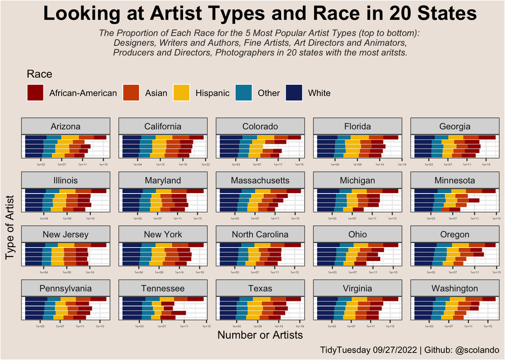

```r
df %>%
  ggplot()+
  geom_bar(aes(x = reorder_within(type,artists_n, state), y = artists_n,  fill = race), position = "stack", stat = "identity")+
    theme_bw()+
  theme(axis.text.y = element_blank(),axis.text.x = element_text(size = 3), axis.ticks.y = element_blank(), legend.position = "top", legend.justification = "left", plot.background = element_rect(fill ="seashell2"), legend.background = element_rect(fill ="seashell2"), plot.title = element_text(face = "bold", size = 20, hjust = 0.5), plot.subtitle = element_text(face = "italic", size = 9, hjust = 0.5, color = "grey20"))+
  scale_x_reordered()+
  coord_flip()+
  scale_y_continuous(trans='log10')+
  facet_wrap(~state, scales = "free")+
  ylab("Number or Artists")+
  xlab("Type of Artist")+
  scale_fill_manual(values = MetBrewer::met.brewer("Johnson"))+
 #scale_fill_brewer(palette = "OrRd")+
  guides(fill = guide_legend(title.position = "top", title = "Race"))+
  labs(subtitle = "The Proportion of Each Race for the 5 Most Popular Artist Types (top to bottom): \nDesigners, Writers and Authors, Fine Artists, Art Directors and Animators,\nProducers and Directors, Photographers in 20 states with the most aritsts.", title = "Looking at Artist Types and Race in 20 States", caption = "TidyTuesday 09/27/2022 | Github: @scolando")
```

```r
ggsave("artists_1.png",plot = last_plot(), width = 10, height = 7, dpi = 500)
```

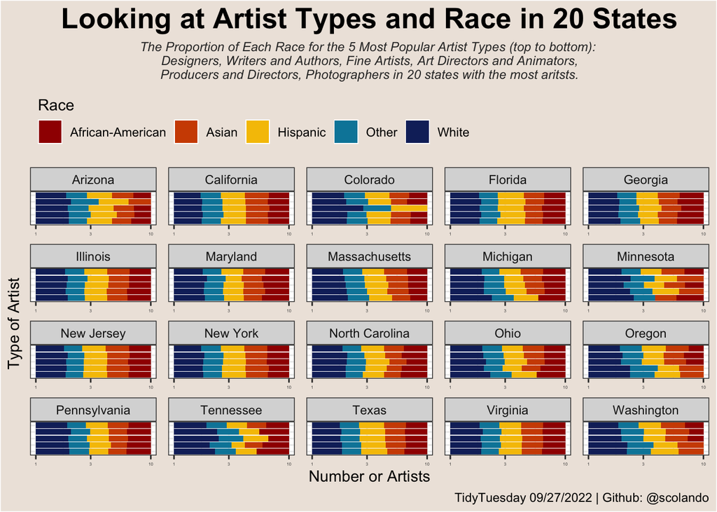

```r
df %>%
  ggplot()+
  geom_bar(aes(x = reorder_within(type,artists_n, state), y = artists_n,  fill = race), position = "fill", stat = "identity")+
    theme_bw()+
  theme(axis.text.y = element_blank(),axis.text.x = element_text(size = 3), axis.ticks.y = element_blank(), legend.position = "top", legend.justification = "left", plot.background = element_rect(fill ="seashell2"), legend.background = element_rect(fill ="seashell2"), plot.title = element_text(face = "bold", size = 20, hjust = 0.5), plot.subtitle = element_text(face = "italic", size = 9, hjust = 0.5, color = "grey20"))+
  scale_x_reordered()+
  coord_flip()+
  scale_y_continuous(trans='log10')+
  facet_wrap(~state, scales = "free")+
  ylab("Number or Artists")+
  xlab("Type of Artist")+
  scale_fill_manual(values = MetBrewer::met.brewer("Johnson"))+
 #scale_fill_brewer(palette = "OrRd")+
  guides(fill = guide_legend(title.position = "top", title = "Race"))+
  labs(subtitle = "The Proportion of Each Race for the 5 Most Popular Artist Types (top to bottom): \nDesigners, Writers and Authors, Fine Artists, Art Directors and Animators,\nProducers and Directors, Photographers in 20 states with the most aritsts.", title = "Looking at Artist Types and Race in 20 States", caption = "TidyTuesday 09/27/2022 | Github: @scolando")
```

```r
ggsave("artists_2.png",plot = last_plot(), width = 10, height = 7, dpi = 500)
```

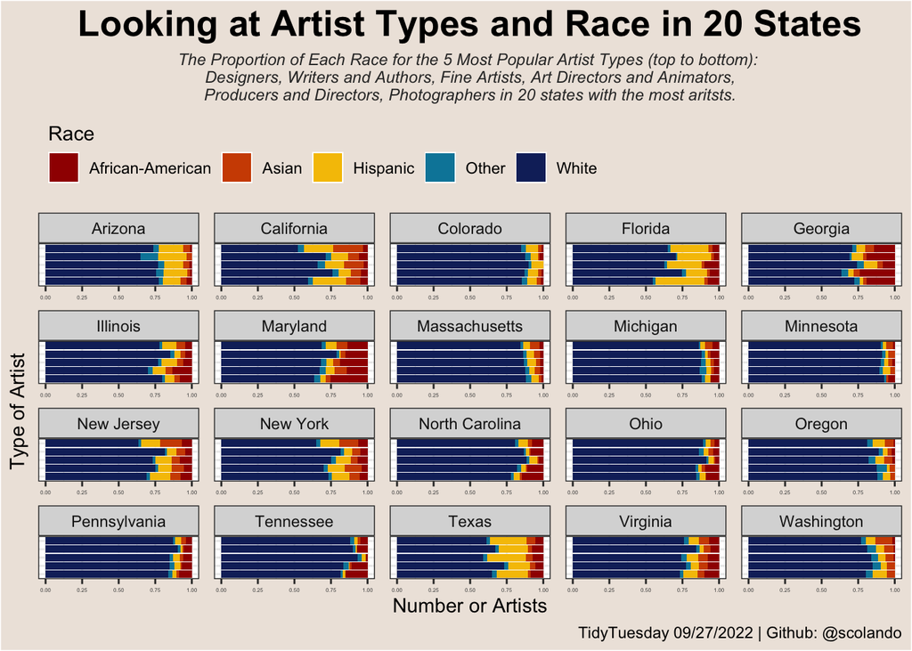

```r
df %>%
  ggplot()+
  geom_bar(aes(x = reorder_within(type,artists_n, state), y = artists_n,  fill = race), position = "fill", stat = "identity")+
    theme_bw()+
  theme(axis.text.y = element_blank(),axis.text.x = element_text(size = 3), axis.ticks.y = element_blank(), legend.position = "top", legend.justification = "left", plot.background = element_rect(fill ="seashell2"), legend.background = element_rect(fill ="seashell2"), plot.title = element_text(face = "bold", size = 20, hjust = 0.5), plot.subtitle = element_text(face = "italic", size = 9, hjust = 0.5, color = "grey20"))+
  scale_x_reordered()+
  coord_flip()+
  facet_wrap(~state, scales = "free")+
  ylab("Number or Artists")+
  xlab("Type of Artist")+
  scale_fill_manual(values = MetBrewer::met.brewer("Johnson"))+
 #scale_fill_brewer(palette = "OrRd")+
  guides(fill = guide_legend(title.position = "top", title = "Race"))+
  labs(subtitle = "The Proportion of Each Race for the 5 Most Popular Artist Types (top to bottom): \nDesigners, Writers and Authors, Fine Artists, Art Directors and Animators,\nProducers and Directors, Photographers in 20 states with the most aritsts.", title = "Looking at Artist Types and Race in 20 States", caption = "TidyTuesday 09/27/2022 | Github: @scolando")
```

```r
ggsave("artists_3.png",plot = last_plot(), width = 10, height = 7, dpi = 500)
```

*also HUGE shoutout to MetBrewer R package for the pretty fill color palette – felt very apt given this week’s TidyTuesday data theme.*

```r
praise::praise()
```

```
## [1] "You are dandy!"
```